# Final Project Draft

Yifei Deng

November 24th, 2017

*Source file* ⇒ Final_Project_Draft.Rmd  
###About the Data Set

#### Reason

The primary reason that I chose this climate data set is because Shenzhen is my homwtown back in China and I lived there for about nearly 20 years. And it was an incident that I found this [website](https://en.tutiempo.net/climate/ws-594930.html) from the [link](https://www.datasciencecentral.com/profiles/blogs/great-github-list-of-public-data-sets) from the final project pdf that it actually show every single years climate for Shenzhen from 1957 to 2017. Since the weather in Shenzhen is so unpredictable from my own experience, I really interested in wrangling this data set and see what I could cram out from it or at least to see some visualized data from it.

#### Description

This dataset contains 15 climate attributions as well as day on 670 individual days from January 2016 to end of the October 2017 from Shenzhen, a tropical area and economic special zone in China.

#### Variable Description

| Variables | Definition |
| --- | --- |
| `Aver_temp` | Average Temperature (C) |
| `Max_temp` | Maximum temperature (C) |
| `Min_temp` | Minimum temperature (C) |
| `Atom_press_sea` | Atmospheric pressure at sea level (hPa) |
| `Aver_hum` | Average relative humidity (%) |
| `Total_rain_or_snow` | Total rainfall and / or snowmelt (mm) |
| `Aver_vis` | Average visibility (Km) |
| `Aver_windsp` | Average wind speed (Km/h) |
| `Max_sus_windsp` | Maximum sustained wind speed (Km/h) |
| `Max_windsp` | Maximum speed of wind (Km/h) |
| `Rain_or_dizz` | Indica whether there was rain or drizzle (In the monthly average, the total days it rained) |
| `Snow` | Indica if it snowed (In the monthly average, the total days it snowed) |
| `Storm` | Indicates whether there storm (In the monthly average, Total days with thunderstorm) |
| `Fog` | Indicates whether there was fog (In the monthly average, Total days with fog) |

#### Reference

[Raw Data](https://en.tutiempo.net/climate/ws-594930.html)

### Data Scraping Steps

**Successfully scrape raw data for climate in 2016 to 2017/10 Shenzhen from the page**

```r
#Get the xpath for the table (actually the same as for each month data from 2017 and 2016)
xpath <- '//*[@id="ColumnaIzquierda"]/div/div[4]/table'
```

```r
#for 2016

#Get the data from January------
page1 <- "https://en.tutiempo.net/climate/01-2016/ws-594930.html"

table_list1 <-
  page1 %>%
  read_html() %>%
  html_nodes(xpath = xpath) %>%
  html_table(fill = TRUE)

Jan <- table_list1[[1]]

Jan <- Jan[-c(32, 33), ]

#Get the data from February------
page2 <- "https://en.tutiempo.net/climate/02-2016/ws-594930.html"

table_list2 <-
  page2 %>%
  read_html() %>%
  html_nodes(xpath = xpath) %>%
  html_table(fill = TRUE)

Feb <- table_list2[[1]]

Feb <- Feb[-c(30, 31), ]
#Get the data from March------
page3 <- "https://en.tutiempo.net/climate/03-2016/ws-594930.html"

table_list3 <-
  page3 %>%
  read_html() %>%
  html_nodes(xpath = xpath) %>%
  html_table(fill = TRUE)

Mar <- table_list3[[1]]

Mar <- Mar[-c(32, 33), ]

#Get the data from April------
page4 <- "https://en.tutiempo.net/climate/04-2016/ws-594930.html"

table_list4 <-
  page4 %>%
  read_html() %>%
  html_nodes(xpath = xpath) %>%
  html_table(fill = TRUE)

Apr <- table_list4[[1]]

Apr <- Apr[-c(31, 32), ]
#Get the data from May------
page5 <- "https://en.tutiempo.net/climate/05-2016/ws-594930.html"

table_list5 <-
  page5 %>%
  read_html() %>%
  html_nodes(xpath = xpath) %>%
  html_table(fill = TRUE)

May <- table_list5[[1]]

May <- May[-c(32, 33), ]
#Get the data from June------
page6 <- "https://en.tutiempo.net/climate/06-2016/ws-594930.html"

table_list6 <-
  page6 %>%
  read_html() %>%
  html_nodes(xpath = xpath) %>%
  html_table(fill = TRUE)

June <- table_list6[[1]]

June <- June[-c(31, 32), ]
#Get the data from July------
page7 <- "https://en.tutiempo.net/climate/07-2016/ws-594930.html"

table_list7 <-
  page7 %>%
  read_html() %>%
  html_nodes(xpath = xpath) %>%
  html_table(fill = TRUE)

July <- table_list7[[1]]

July <- July[-c(32, 33), ]
#Get the data from August------
page8 <- "https://en.tutiempo.net/climate/08-2016/ws-594930.html"

table_list8 <-
  page8 %>%
  read_html() %>%
  html_nodes(xpath = xpath) %>%
  html_table(fill = TRUE)

Aug <- table_list8[[1]]

Aug <- Aug[-c(32, 33), ]
#Get the data from September------
page9 <- "https://en.tutiempo.net/climate/09-2016/ws-594930.html"

table_list9 <-
  page9 %>%
  read_html() %>%
  html_nodes(xpath = xpath) %>%
  html_table(fill = TRUE)

Sep <- table_list9[[1]]

Sep <- Sep[-c(31, 32), ]
#Get the data from October------
page10 <- "https://en.tutiempo.net/climate/10-2016/ws-594930.html"

table_list10 <-
  page10 %>%
  read_html() %>%
  html_nodes(xpath = xpath) %>%
  html_table(fill = TRUE)

Oct <- table_list10[[1]]

Oct <- Oct[-c(32, 33), ]
#Get the data from November------
page11 <- "https://en.tutiempo.net/climate/11-2016/ws-594930.html"

table_list11 <-
  page11 %>%
  read_html() %>%
  html_nodes(xpath = xpath) %>%
  html_table(fill = TRUE)

Nov <- table_list11[[1]]

Nov <- Nov[-c(31, 32), ]
#Get the data from December------
page12 <- "https://en.tutiempo.net/climate/12-2016/ws-594930.html"

table_list12 <-
  page12 %>%
  read_html() %>%
  html_nodes(xpath = xpath) %>%
  html_table(fill = TRUE)

Dec <- table_list12[[1]]

Dec <- Dec[-c(32, 33), ]
```

```r
#for 2017

#Get the data from January------
page1_1 <- "https://en.tutiempo.net/climate/01-2017/ws-594930.html"

table_list1_1 <-
  page1_1 %>%
  read_html() %>%
  html_nodes(xpath = xpath) %>%
  html_table(fill = TRUE)

Jan1 <- table_list1_1[[1]]

Jan1 <- Jan1[-c(32, 33), ]

#Get the data from Februray------
page1_2 <- "https://en.tutiempo.net/climate/02-2017/ws-594930.html"

table_list1_2 <-
  page1_2 %>%
  read_html() %>%
  html_nodes(xpath = xpath) %>%
  html_table(fill = TRUE)

Feb1 <- table_list1_2[[1]]

Feb1 <- Feb1[-c(29, 30), ]


#Get the data from March------
page1_3 <- "https://en.tutiempo.net/climate/03-2017/ws-594930.html"

table_list1_3 <-
  page1_3 %>%
  read_html() %>%
  html_nodes(xpath = xpath) %>%
  html_table(fill = TRUE)

Mar1 <- table_list1_3[[1]]

Mar1 <- Mar1[-c(32, 33), ]
#Get the data from April------
page1_4 <- "https://en.tutiempo.net/climate/04-2017/ws-594930.html"

table_list1_4 <-
  page1_4 %>%
  read_html() %>%
  html_nodes(xpath = xpath) %>%
  html_table(fill = TRUE)

Apr1 <- table_list1_4[[1]]

Apr1 <- Apr1[-c(31, 32), ]
#Get the data from May------
page1_5 <- "https://en.tutiempo.net/climate/05-2017/ws-594930.html"

table_list1_5 <-
  page1_5 %>%
  read_html() %>%
  html_nodes(xpath = xpath) %>%
  html_table(fill = TRUE)

May1 <- table_list1_5[[1]]

May1 <- May1[-c(32, 33), ]
#Get the data from June------
page1_6 <- "https://en.tutiempo.net/climate/06-2017/ws-594930.html"

table_list1_6 <-
  page1_6 %>%
  read_html() %>%
  html_nodes(xpath = xpath) %>%
  html_table(fill = TRUE)

June1 <- table_list1_6[[1]]

June1 <- June1[-c(31, 32), ]
#Get the data from July------
page1_7 <- "https://en.tutiempo.net/climate/07-2017/ws-594930.html"

table_list1_7 <-
  page1_7 %>%
  read_html() %>%
  html_nodes(xpath = xpath) %>%
  html_table(fill = TRUE)

July1 <- table_list1_7[[1]]

July1 <- July1[-c(32, 33), ]
#Get the data from August------
page1_8 <- "https://en.tutiempo.net/climate/08-2017/ws-594930.html"

table_list1_8 <-
  page1_8 %>%
  read_html() %>%
  html_nodes(xpath = xpath) %>%
  html_table(fill = TRUE)

Aug1 <- table_list1_8[[1]]

Aug1 <- Aug1[-c(32, 33), ]
#Get the data from September------
page1_9 <- "https://en.tutiempo.net/climate/09-2017/ws-594930.html"

table_list1_9 <-
  page1_9 %>%
  read_html() %>%
  html_nodes(xpath = xpath) %>%
  html_table(fill = TRUE)

Sep1 <- table_list1_9[[1]]

Sep1 <- Sep1[-c(31, 32), ]
#Get the data from October------
page1_10 <- "https://en.tutiempo.net/climate/10-2017/ws-594930.html"

table_list1_10 <-
  page1_10 %>%
  read_html() %>%
  html_nodes(xpath = xpath) %>%
  html_table(fill = TRUE)

Oct1 <- table_list1_10[[1]]

Oct1 <- Oct1[-c(32, 33), ]
```

**Combine the data from 2016 to 2017/10 in Shenzhen to one whole year data set**

```r
#Combine this 2016 and 2017 climate data for each month into one whole year data set------
Weather_ShenZhen <-
  Jan %>%
  full_join(Feb) %>%
  full_join(Mar) %>%
  full_join(Apr) %>%
  full_join(May) %>%
  full_join(June) %>%
  full_join(July) %>%
  full_join(Aug) %>%
  full_join(Sep) %>%
  full_join(Oct) %>%
  full_join(Nov) %>%
  full_join(Dec) %>%
  full_join(Jan1) %>%
  full_join(Feb1) %>%
  full_join(Mar1) %>%
  full_join(Apr1) %>%
  full_join(May1) %>%
  full_join(June1) %>%
  full_join(July1) %>%
  full_join(Aug1) %>%
  full_join(Sep1) %>%
  full_join(Oct1)


#Revise the names for the data set to its reality names------
Weather_ShenZhen <-
  Weather_ShenZhen %>%
  mutate(Date = seq(as.Date("2016/1/1"), as.Date("2017/10/31"), by = "day")) %>%
  rename(Aver_temp = "T", Max_temp = "TM", Min_temp = "Tm", Atom_press_sea = "SLP", Aver_hum = "H", Total_rain_or_snow = "PP", Aver_vis = "VV", Aver_windsp = "V", Max_sus_windsp = "VM", Max_windsp = "VG", Rain_or_driz = "RA", Snow = "SN", Storm = "TS", Fog = "FG")

Weather_ShenZhen = Weather_ShenZhen[,-c(1)]
```

**Write out the data set so that we could work on it easily without revising it**

```r
write.csv(Weather_ShenZhen, "~/Desktop/STAT184/Final Project/Weather_ShenZhen.csv")
```

### Preparation

```r
#Set work directory
setwd("~/Desktop/STAT184/Final Project")

#Read in the data set we just scraped
Weather = read.csv("~/Desktop/STAT184/Final Project/Weather_ShenZhen.csv")

#Delete the first column with the order numbers and the column with the snow varaible, since Shenzhen is located in the tropical area (no snow exist)
Weather <- Weather[,-c(1)]
Weather <- Weather[,-c(12)]
```

### Start

```r
#inspect the first few obeservations of the data set
head(Weather)
```

```
##   Aver_temp Max_temp Min_temp Atom_press_sea Aver_hum Total_rain_or_snow
## 1      17.9     22.3       15         1025.1       74                  0
## 2      19.3     22.8     15.4         1021.3       80                  0
## 3      19.2       20     17.8         1019.5       96               8.13
## 4      20.7     23.6       19           1018       89               3.81
## 5      20.2       23       18         1016.1       92                6.1
## 6      20.1       25       15         1020.2       70                  0
##   Aver_vis Aver_windsp Max_sus_windsp Max_windsp Rain_or_driz Storm Fog
## 1      6.1         8.5             18          -
## 2      3.4           7           14.4          -            o
## 3      3.2         4.1            7.2          -            o         o
## 4     10.3         5.7           14.4       32.4            o
## 5      6.9         8.5           21.7          -            o     o
## 6     15.9        15.2           28.7          -
##         Date
## 1 2016-01-01
## 2 2016-01-02
## 3 2016-01-03
## 4 2016-01-04
## 5 2016-01-05
## 6 2016-01-06
```

```r
#Inspect the variables by using str() and summary() command
str(Weather)
```

```
## 'data.frame':    670 obs. of  14 variables:
##  $ Aver_temp         : Factor w/ 188 levels "-","10","10.2",..: 52 63 62 76 72 71 56 52 55 51 ...
##  $ Max_temp          : Factor w/ 180 levels "-","10","11",..: 55 59 38 65 61 76 52 52 44 44 ...
##  $ Min_temp          : Factor w/ 184 levels "-","1.7","1.8",..: 39 40 60 70 62 39 41 39 39 44 ...
##  $ Atom_press_sea    : Factor w/ 250 levels "-","1000.2","1000.7",..: 219 188 171 156 138 177 195 183 177 142 ...
##  $ Aver_hum          : Factor w/ 61 levels "-","29","32",..: 38 44 60 53 56 34 33 30 34 49 ...
##  $ Total_rain_or_snow: Factor w/ 120 levels "-","0","0.25",..: 2 2 108 65 95 2 2 2 2 48 ...
##  $ Aver_vis          : Factor w/ 145 levels "-","10","10.1",..: 122 108 107 4 127 39 14 21 8 128 ...
##  $ Aver_windsp       : Factor w/ 100 levels "-","10","10.2",..: 93 85 73 78 93 30 98 6 3 14 ...
##  $ Max_sus_windsp    : Factor w/ 15 levels "-","10.7","14.4",..: 4 3 15 3 5 7 5 5 5 5 ...
##  $ Max_windsp        : Factor w/ 17 levels "-","25.2","28.7",..: 1 1 1 4 1 1 1 1 1 5 ...
##  $ Rain_or_driz      : Factor w/ 3 levels "","-","o": 1 3 3 3 3 1 1 1 1 3 ...
##  $ Storm             : Factor w/ 3 levels "","-","o": 1 1 1 1 3 1 1 1 1 1 ...
##  $ Fog               : Factor w/ 3 levels "","-","o": 1 1 3 1 1 1 1 1 1 1 ...
##  $ Date              : Factor w/ 670 levels "2016-01-01","2016-01-02",..: 1 2 3 4 5 6 7 8 9 10 ...
```

```r
summary(Weather)
```

```
##    Aver_temp      Max_temp      Min_temp   Atom_press_sea    Aver_hum
##  29.7   : 14   30     : 28   25     : 16   1008.3 : 15    83     : 37
##  29.4   : 12   29     : 26   26     : 16   1008.8 : 10    85     : 34
##  28.1   : 11   31     : 25   14     : 15   1009   :  9    77     : 30
##  29.1   : 11   32     : 25   15     : 14   1013.2 :  9    78     : 29
##  29.3   : 10   28     : 21   26.6   : 13   1008.1 :  8    79     : 26
##  29.6   : 10   33     : 21   22     : 12   1009.3 :  8    84     : 26
##  (Other):602   (Other):524   (Other):584   (Other):611    (Other):488
##  Total_rain_or_snow    Aver_vis    Aver_windsp  Max_sus_windsp
##  0      :346        18.3   : 15   10.6   : 35   21.7   :181
##  0.25   : 28        18.8   : 15   9.8    : 23   18     :138
##  0.51   : 23        17.2   : 14   9.1    : 22   25.2   :114
##  -      : 19        19.5   : 14   12.2   : 19   28.7   : 92
##  1.02   : 12        15.6   : 13   11.5   : 17   14.4   : 72
##  0.76   : 11        16.4   : 13   8.3    : 17   32.4   : 36
##  (Other):231        (Other):586   (Other):537   (Other): 37
##    Max_windsp  Rain_or_driz Storm   Fog             Date
##  -      :601    :348         :586    :655   2016-01-01:  1
##  32.4   : 11   -:  2        -:  2   -:  2   2016-01-02:  1
##  39.6   : 10   o:320        o: 82   o: 13   2016-01-03:  1
##  35.9   :  9                                2016-01-04:  1
##  28.7   :  7                                2016-01-05:  1
##  43.2   :  7                                2016-01-06:  1
##  (Other): 25                                (Other)   :664
```

### 1.Fundamental Exploratory Analysis

**Firstly, we want to know what is the average temperature during these two year period. And show the specific date that the temperature would exceed this average with the count of it**

```r
#Calculate out the mean value of the temperature during the date range
Weather %>%
  mutate(num_Aver_temp = tidyr::extract_numeric(Aver_temp)) %>%
  na.omit() %>%
  summarise(Aver_temp_two = sum(num_Aver_temp)/nrow(Weather))
```

```
##   Aver_temp_two
## 1      23.99806
```

```r
#Use the threhold(i.e. mean temperature) to show the specific date that the temperature would exceed this average
Spec_date <-
  Weather %>%
  na.omit() %>%
  filter(readr::parse_number(Aver_temp) > 23.99806) %>%
  select(Date,Aver_temp)

#inspect the first few date with temperature greater than the average temperature during the two-year-period
head(Spec_date)
```

```
##         Date Aver_temp
## 1 2016-04-06      24.3
## 2 2016-04-07      25.2
## 3 2016-04-08      24.9
## 4 2016-04-09      24.7
## 5 2016-04-14      24.4
## 6 2016-04-16      25.7
```

```r
#show the count of the dates that have the greater temperature
nrow(Spec_date)
```

```
## [1] 390
```

**Secondly, we are curious about the most frequent weather conditons in Shenzhen**

```r
Weather %>%
  filter(Storm == "o") %>%
  summarise(count_storm = sum(n()))
```

```
##   count_storm
## 1          82
```

```r
Weather %>%
  filter(Fog == "o") %>%
  summarise(count_fog = sum(n()))
```

```
##   count_fog
## 1        13
```

```r
Weather %>%
  filter(Rain_or_driz == "o") %>%
  summarise(count_rain = sum(n()))
```

```
##   count_rain
## 1        320
```

`Conclusion:`

From above report, we could conclude that the most frequent weather conditions is rain or drizzle in Shenzhen.

**Thirdly and lastly, we want to know whether the change of temperature during each day would be different under the condition of single,mixture or no weather conditions or any possible weather condition**

```r
#First we will need to create a factor variable with different levels
Weather <-
  Weather %>%
  mutate(Conditions =
           ifelse(Rain_or_driz == "o"&Storm == "o"&Fog == "o",
                  "Rain_or_driz & Storm &Fog",
                  ifelse(Rain_or_driz == "o"& Fog == "o",
                         "Rain_or_driz & Fog",
                         ifelse(Rain_or_driz == "o"&Storm == "o",
                                "Rain_or_driz & Storm",
                                ifelse(Rain_or_driz == "o",
                                       "Rain_or_driz",
                                       ifelse(Storm == "o",
                                              "Storm",
                                              ifelse(Fog == "o",
                                                     "Fog","-")))))))

#inspect the data set
head(Weather)
```

```
##   Aver_temp Max_temp Min_temp Atom_press_sea Aver_hum Total_rain_or_snow
## 1      17.9     22.3       15         1025.1       74                  0
## 2      19.3     22.8     15.4         1021.3       80                  0
## 3      19.2       20     17.8         1019.5       96               8.13
## 4      20.7     23.6       19           1018       89               3.81
## 5      20.2       23       18         1016.1       92                6.1
## 6      20.1       25       15         1020.2       70                  0
##   Aver_vis Aver_windsp Max_sus_windsp Max_windsp Rain_or_driz Storm Fog
## 1      6.1         8.5             18          -
## 2      3.4           7           14.4          -            o
## 3      3.2         4.1            7.2          -            o         o
## 4     10.3         5.7           14.4       32.4            o
## 5      6.9         8.5           21.7          -            o     o
## 6     15.9        15.2           28.7          -
##         Date           Conditions
## 1 2016-01-01                    -
## 2 2016-01-02         Rain_or_driz
## 3 2016-01-03   Rain_or_driz & Fog
## 4 2016-01-04         Rain_or_driz
## 5 2016-01-05 Rain_or_driz & Storm
## 6 2016-01-06                    -
```

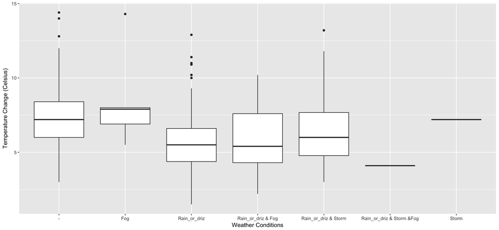

```r
#Now,create the boxplot for each possible weather conditions
Weather %>%
  na.omit() %>%
  mutate(diff = tidyr::extract_numeric(Max_temp)-tidyr::extract_numeric(Min_temp)) %>%
  ggplot(aes(x = Conditions, y = diff)) +
  geom_boxplot() +
  xlab("Weather Conditions") +
  ylab("Temperature Change (Celsius)")
```

```r
#We could then create an factor variables with 3 levels with no weather condition, single weather & mixture of weather based on the conditions variable we just created
Weather <-
  Weather %>%
  na.omit() %>%
  mutate(Single_no_Mix =
           ifelse(Conditions == grep("-", Conditions, value = TRUE),
                  "No Weather Condition",
                  ifelse(Conditions ==grep("^[R][^&-]*$",Conditions, value = TRUE),
                         "Single",
                         ifelse(Conditions == grep("^[Fog]",Conditions, value = TRUE),
                                "Single",
                                ifelse(Conditions == grep("^[Storm]", Conditions, value = TRUE),
                                       "Single",
                                       "Mixture of Weather")))))
#inspect the data set
head(Weather)
```

```
##   Aver_temp Max_temp Min_temp Atom_press_sea Aver_hum Total_rain_or_snow
## 1      17.9     22.3       15         1025.1       74                  0
## 2      19.3     22.8     15.4         1021.3       80                  0
## 3      19.2       20     17.8         1019.5       96               8.13
## 4      20.7     23.6       19           1018       89               3.81
## 5      20.2       23       18         1016.1       92                6.1
## 6      20.1       25       15         1020.2       70                  0
##   Aver_vis Aver_windsp Max_sus_windsp Max_windsp Rain_or_driz Storm Fog
## 1      6.1         8.5             18          -
## 2      3.4           7           14.4          -            o
## 3      3.2         4.1            7.2          -            o         o
## 4     10.3         5.7           14.4       32.4            o
## 5      6.9         8.5           21.7          -            o     o
## 6     15.9        15.2           28.7          -
##         Date           Conditions        Single_no_Mix
## 1 2016-01-01                    - No Weather Condition
## 2 2016-01-02         Rain_or_driz               Single
## 3 2016-01-03   Rain_or_driz & Fog   Mixture of Weather
## 4 2016-01-04         Rain_or_driz               Single
## 5 2016-01-05 Rain_or_driz & Storm   Mixture of Weather
## 6 2016-01-06                    - No Weather Condition
```

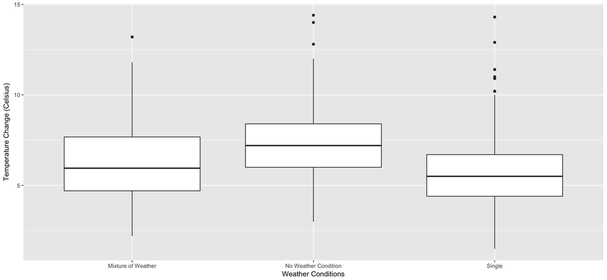

```r
#Now,recreate another boxplot and see the differences between no weather, single weather and mixture of Weather
Weather %>%
  na.omit() %>%
  mutate(diff = tidyr::extract_numeric(Max_temp)-tidyr::extract_numeric(Min_temp)) %>%
  ggplot(aes(x = Single_no_Mix, y = diff)) +
  geom_boxplot() +
  xlab("Weather Conditions") +
  ylab("Temperature Change (Celsius)")
```

`Observations:`

**From the boxplot of any possible weather conditions**

- From the box plot, the change of temperature during each day would be mostly different under the condition of either single or mixture of weather condition, except between raining or drizzle and the mixture of raining or drizzle & Fog (since they have close mean and variability).
- In addition, since the average temperature changes of raining or drizzle and mixture of raining or drizzle & Fog are nearly the same, we could also say that Fog would have small influence on the change of temperature.

**From the boxplot of no,snigle and mixture weather conditions**

- The change of temperature during each day would be different under the condition of single, mixture or no weather conditions

### 2. Correlations Between certain variables?

#### Part 1

**In this part, we want to investigate whether there is correlation between Average temperature and Atmospheric pressure at sea level in the area of Shenzhen taking into considerations single, mixture of weather or no weather conditions**

[figure not shown]

```r
Weather %>%
  ggplot(aes(x=Aver_temp,y=Atom_press_sea)) +
  geom_point(aes(colour = Conditions)) +
  facet_wrap( ~ Single_no_Mix) +
  theme(axis.text.x=element_text(angle=60,hjust=1,size=16),axis.text.y=element_text(size=16),axis.title=element_text(size=16,face="bold"))
```

`Observations`:

Based on the graphs provided above, we could conclude that there is a seemly negative correlation between the average temperature and the atmosphere pressure at the sea level in Shenzhen in any of the conditions provided. (i.e. as the average temperature increase, the atmosphere pressure at the sea level would possibly decrease in the region in Shenzhen)

#### Part 2

**Next, as many people may have concerned that there was always a rumor saying that the change of temperature would have a hugly impact on the humdity from which the effects would show significances in many tropical area like Shenzhen. Thus, in this part we want to test the validity of this statement**

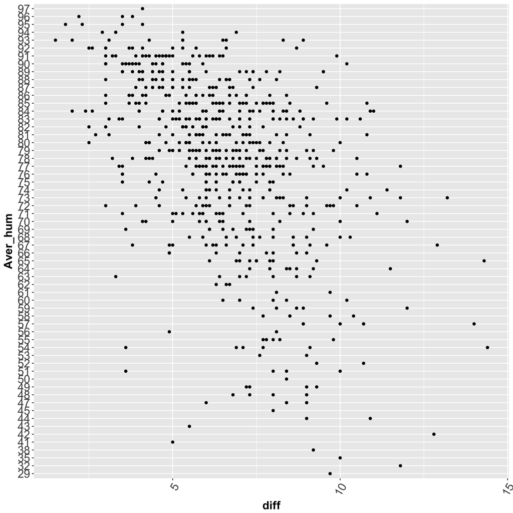

```r
#In this part, we first define the change in temperature and next we omit the NA and then we create a plot frame and plot with difference of the temperture V.S. the average relative humidity to see the relationship.
Weather %>%
  mutate(diff = tidyr::extract_numeric(Max_temp)-tidyr::extract_numeric(Min_temp)) %>%
  na.omit() %>%
  ggplot(aes(x=diff,y=Aver_hum)) +
  geom_point() +
  theme(axis.text.x=element_text(angle=60,hjust=1,size=16),axis.text.y=element_text(size=16),axis.title=element_text(size=16,face="bold"))
```

`Conclusion`:

According to the diff V.S. Average relative humidity plot, we could conclude that the change of temperature would indeed have a hugely impact on the humidity, however, in a negative way. (i.e. as the change of the temperature increase, the average relative humidity would decrease correspondingly in Shenzhen)

### 3. When did the humidity would Change?

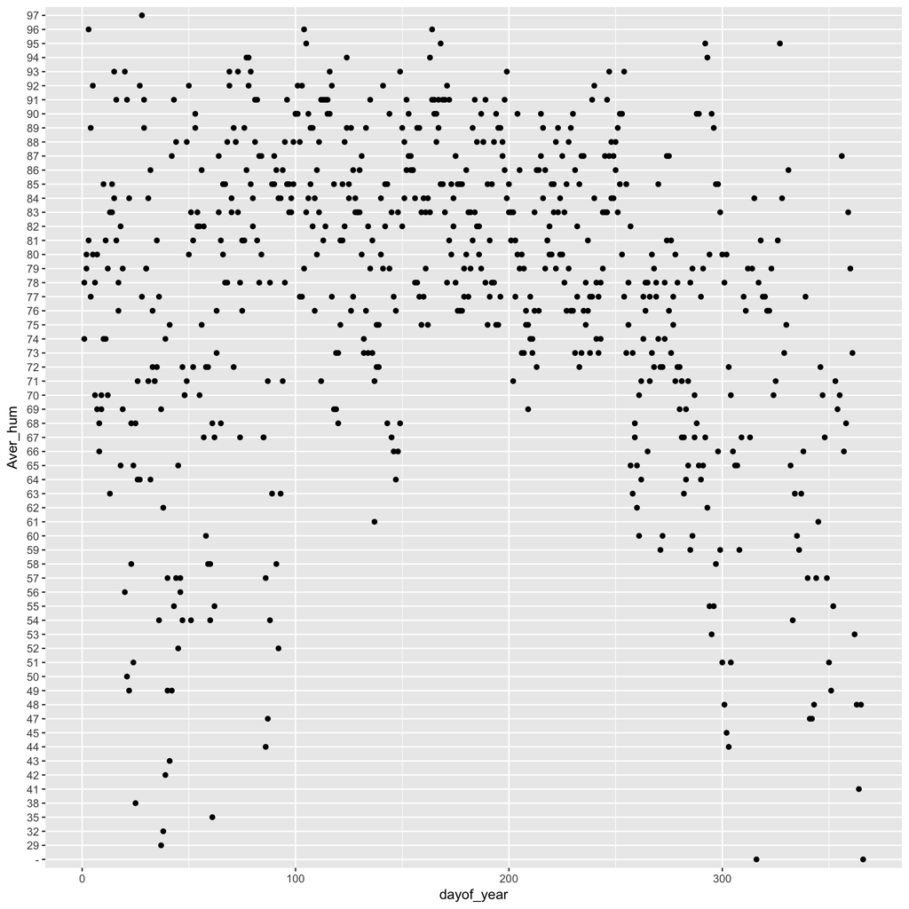

```r
#The general pattern during the two-year-peroid
Weather %>%
  mutate(dayof_year = lubridate::yday(Date)) %>%
  ggplot(aes(x = dayof_year,y=Aver_hum)) +
  geom_point()
```

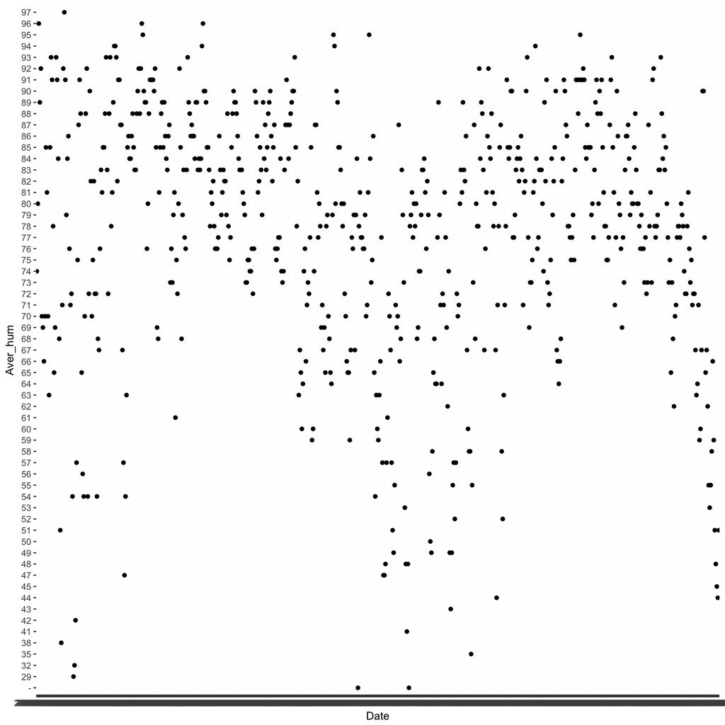

```r
#To check whether the pattern is accurate, check the plot with the whole year
Weather %>%
  ggplot(aes(x = Date,y=Aver_hum)) +
  geom_point()
```

```r
#Check!(repeated within the same pattern)
```

`Observations`:

### (To be Continued, not finished yet)